# ゲームハード週販レポート (2026.04.26)

```
The autoreload extension is already loaded. To reload it, use:
  %reload_ext autoreload
```

国内ゲームハード週販レポート (2026-04-26)

- ハードウェアの販売データはファミ通の調査結果を基にしています。
- 一部のデータは処理上の都合により、週次値に調整しています｡
- 過去の週販レポート

## 直近4週間のハード売り上げ／累計推移

| 集計日 | ハード | 販売台数 | 前週差 | 累計台数 | 週数 |
| --- | --- | --- | --- | --- | --- |
| 2026-04-05 | Nintendo Switch2 | 59,543 | -6,182 | 5,011,059 | 44 |
|  | Nintendo Switch | 16,342 | -2,200 | 36,701,356 | 475 |
|  | PlayStation5 | 13,539 | -5,865 | 7,500,537 | 282 |
|  | Xbox Series X\|S | 932 | +492 | 697,563 | 282 |
| 2026-04-12 | Nintendo Switch2 | 52,058 | -7,485 | 5,063,117 | 45 |
|  | Nintendo Switch | 21,134 | +4,792 | 36,722,490 | 476 |
|  | PlayStation5 | 8,673 | -4,866 | 7,509,210 | 283 |
|  | Xbox Series X\|S | 685 | -247 | 698,248 | 283 |
| 2026-04-19 | Nintendo Switch2 | 44,280 | -7,778 | 5,107,397 | 46 |
|  | Nintendo Switch | 31,496 | +10,362 | 36,753,986 | 477 |
|  | PlayStation5 | 10,730 | +2,057 | 7,519,940 | 284 |
|  | Xbox Series X\|S | 454 | -231 | 698,702 | 284 |
| 2026-04-26 | Nintendo Switch2 | 45,825 | +1,545 | 5,153,222 | 47 |
|  | Nintendo Switch | 27,139 | -4,357 | 36,781,125 | 478 |
|  | PlayStation5 | 12,973 | +2,243 | 7,532,913 | 285 |
|  | Xbox Series X\|S | 246 | -208 | 698,948 | 285 |

Switch2が7週間ぶりに下げ止まって増加しました｡先週から1500台増加の4万5千台です｡ 5万台前後で安定するのであれば特に問題ないでしょう｡ ぽこあポケモンはパッケージ累計92万本､100万本が射程距離内です｡

Switchは4千台下げましたが､それでも高水準の2万7千台｡ Switch Liteの好調が続きます｡ トモダチコレクションは累計74万本､こちらも100万本を目指せるでしょう｡

PS5はさらに2千台増加し1万2千台です｡ 値上げ以降 PS5 Proが以下のように増え続けています｡ よくわからない動きです｡

1219台 → 3066台 → 4330台

## 週販推移

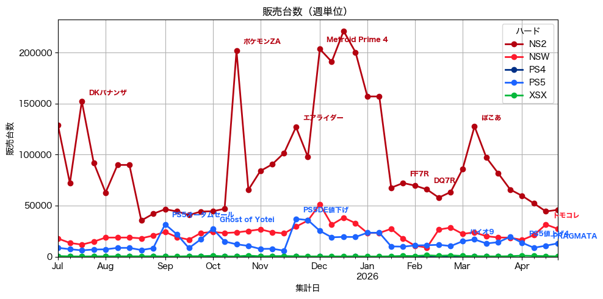

下げ止まったSwitch2｡ スプラトゥーン・レイダースまでは､昨年の9月頃と似た推移をたどると思われます｡

### 週販推移(拡大）

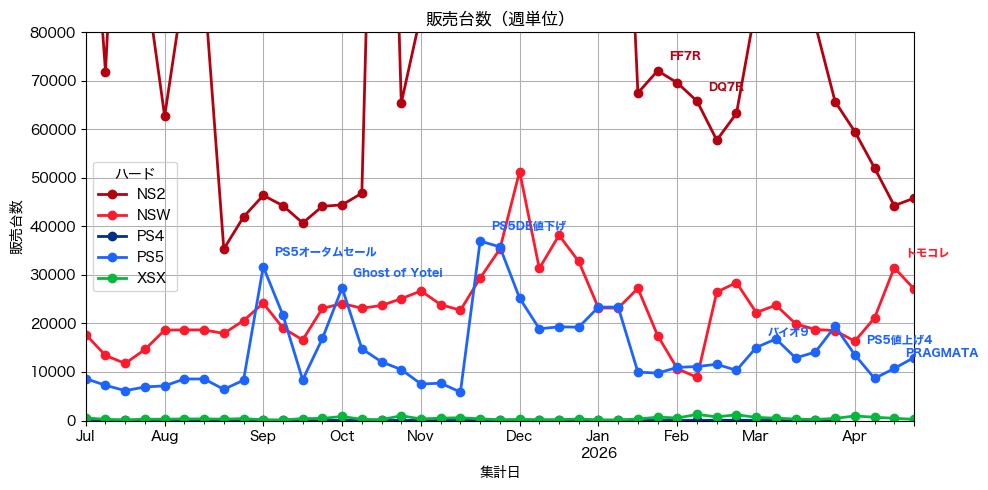

Switch2が5万前後､Switchが3万前後､PS5が1万前後で安定する状況がしばらく続きそうです｡

## 過去年の週販比較

### PlayStation 5: 2023年から2026年の3月1日以降

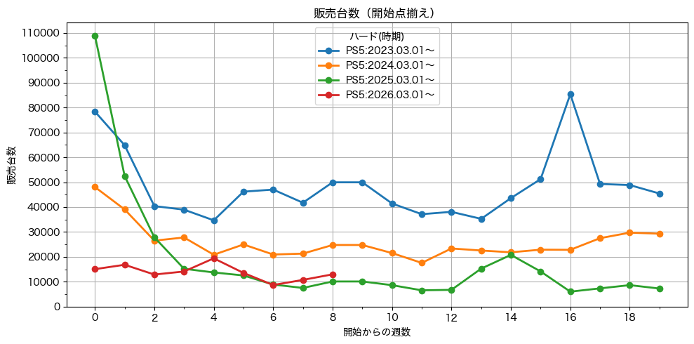

現時点で2026年のPS5は健闘しています｡値上げがありながらも､前年の同時期よりも若干高い販売台数で推移しています｡

### Nintendo Switch2: 2026 と Switch 2018,2019年 3月1日以降

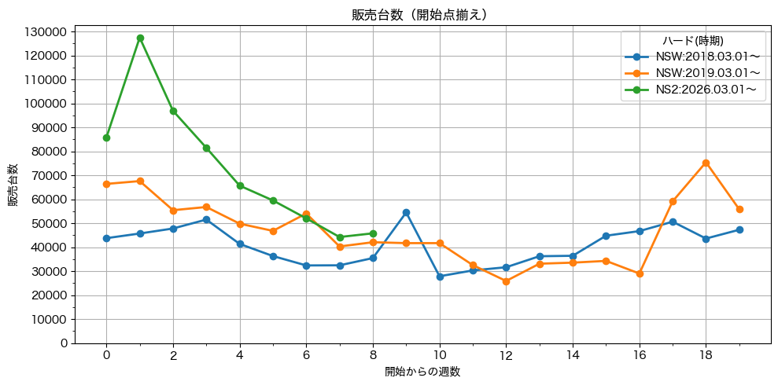

(Switch2は昨年のデータがありませんので､Switchの2018, 2019年の推移と比較します｡)

Switch2の販売ペースは2019年のSwitchと同じ水準で踏みとどまりました｡ このまま5万弱で推移したとしても､ Switchよりも若干高い販売台数で推移することになります｡

## 月間販売推移

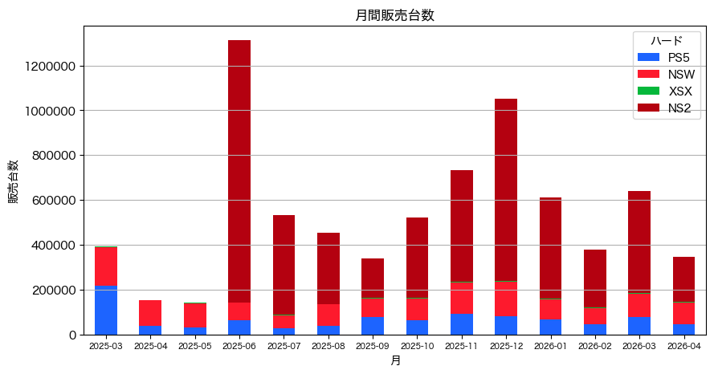

4月としては40万台に届きませんでしたが､昨年4月と比較すればSwitch2分がまるまる加わった値となっており､ 悪くない状況です｡

### Nintendo Switch2: 月間販売台数

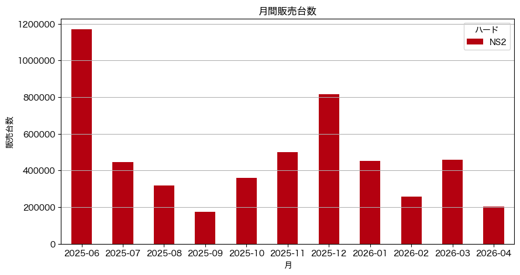

2026年4月のSwitch2の販売台数は昨年9月を超えて､20万台に到達出来ました｡

### Nintendo Switch: 月間販売台数

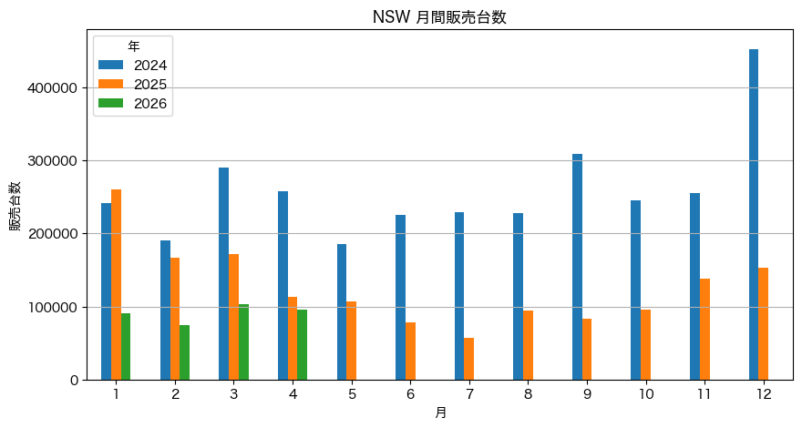

| 月 | 2025 | 2026 | YoY |
| --- | --- | --- | --- |
| 1 | 260,447 | 91,109 | 35.0% |
| 2 | 167,188 | 74,477 | 44.5% |
| 3 | 171,921 | 103,267 | 60.1% |
| 4 | 113,513 | 96,111 | 84.7% |
| 5 | 106,506 | 0 | 0.0% |
| 6 | 78,097 | 0 | 0.0% |
| 7 | 57,532 | 0 | 0.0% |
| 8 | 94,517 | 0 | 0.0% |
| 9 | 82,946 | 0 | 0.0% |
| 10 | 96,080 | 0 | 0.0% |
| 11 | 138,018 | 0 | 0.0% |
| 12 | 153,619 | 0 | 0.0% |

4月のSwitchはトモコレ効果で昨年比84.7%という高い水準でした｡ 次世代機が出ていると思えない好調ぶりです｡

### PlayStation 5: 月間販売台数

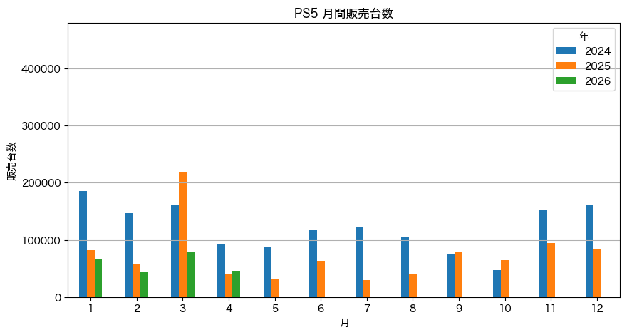

| 月 | 2025 | 2026 | YoY |
| --- | --- | --- | --- |
| 1 | 81,587 | 66,502 | 81.5% |
| 2 | 56,886 | 44,010 | 77.4% |
| 3 | 218,300 | 78,276 | 35.9% |
| 4 | 38,983 | 45,915 | 117.8% |
| 5 | 32,001 | 0 | 0.0% |
| 6 | 63,516 | 0 | 0.0% |
| 7 | 28,959 | 0 | 0.0% |
| 8 | 39,004 | 0 | 0.0% |
| 9 | 78,693 | 0 | 0.0% |
| 10 | 64,732 | 0 | 0.0% |
| 11 | 93,852 | 0 | 0.0% |
| 12 | 82,691 | 0 | 0.0% |

2026年4月のPS5は昨年比で118%と好調でした｡前年同月を上回るのは2025年10月以来です｡

## 累計販売推移

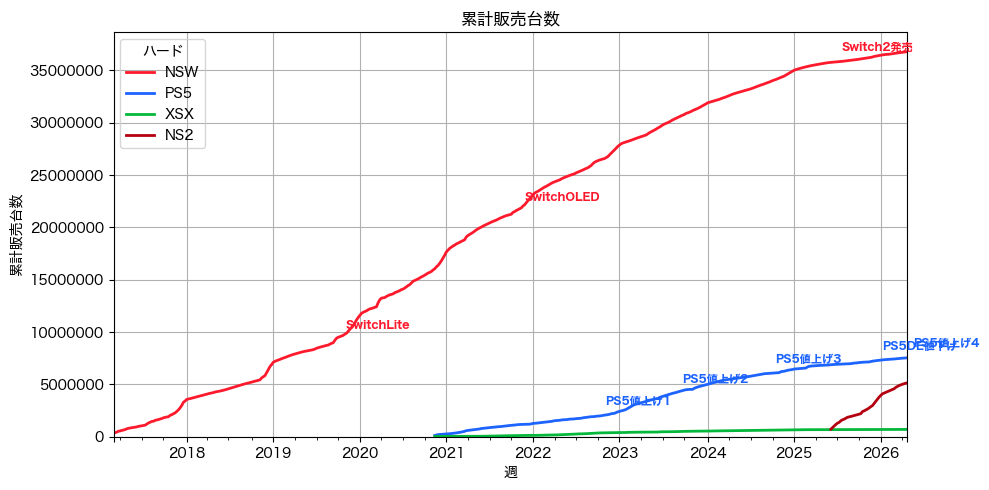

### Switch2: 47週目の状況

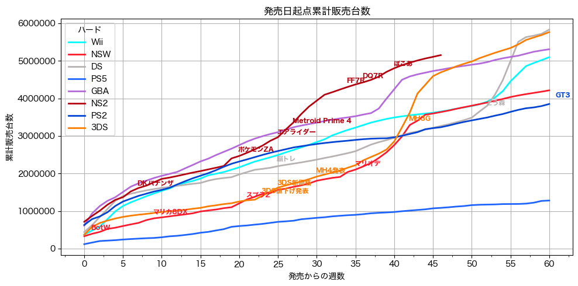

| ハード | 販売数 |
| --- | --- |
| NS2 | 5,153,222 |
| GBA | 4,764,176 |
| 3DS | 4,694,717 |
| Wii | 3,650,397 |
| NSW | 3,636,732 |
| DS | 3,265,160 |
| PS2 | 3,232,624 |
| PS5 | 1,085,018 |

今のペースだと7月後半にはDS,3DSに抜かれそうですが､ スプラトゥーン・レイダースの発売日が7月23日に決まったため､ そこで加速してSwitch2の歴代最速は続きそうです｡

### PS5: 285週目の状況

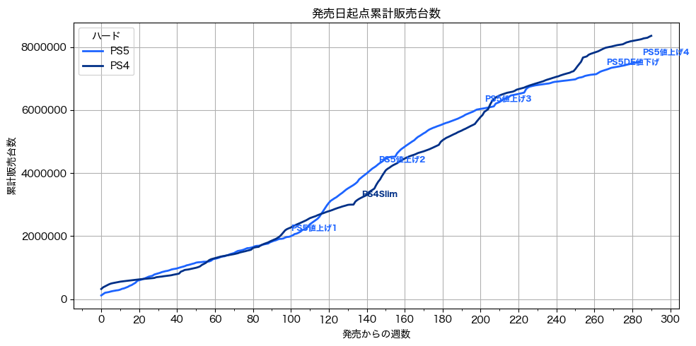

| ハード | 販売数 |
| --- | --- |
| PS4 | 8,241,432 |
| PS5 | 7,532,913 |

PS4とPS5の同時期累計差は71万台前後で安定しています｡差は開いていませんが､縮まってもいません｡

## 年単位の状況

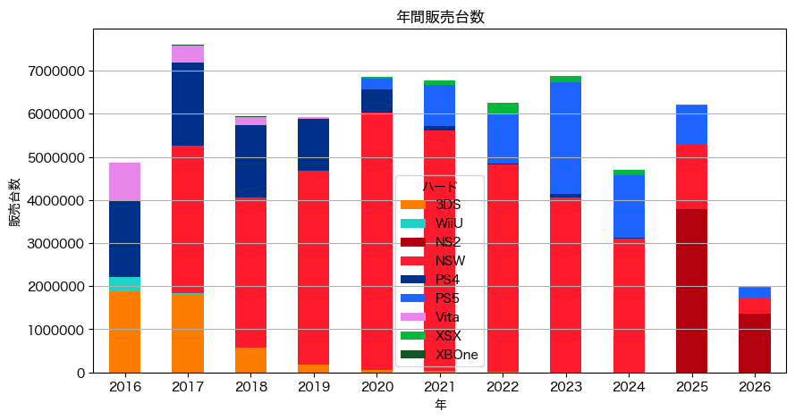

| year | 3DS | WiiU | NS2 | NSW | PS4 | PS5 | Vita | XSX | XBOne | 合計 |
| --- | --- | --- | --- | --- | --- | --- | --- | --- | --- | --- |
| 2016 | 1,874,457 | 336,151 | nan | nan | 1,790,883 | nan | 865,002 | nan | 8,897 | 4,875,390 |
| 2017 | 1,827,131 | 21,817 | nan | 3,407,158 | 1,935,247 | nan | 396,207 | nan | 14,664 | 7,602,224 |
| 2018 | 566,420 | nan | nan | 3,482,388 | 1,695,227 | nan | 181,728 | nan | 15,339 | 5,941,102 |
| 2019 | 191,173 | nan | nan | 4,493,903 | 1,196,153 | nan | 37,668 | nan | 8,315 | 5,927,212 |
| 2020 | 62,761 | nan | nan | 5,956,943 | 542,647 | 255,150 | nan | 31,424 | 3,585 | 6,852,510 |
| 2021 | 28,540 | nan | nan | 5,579,127 | 104,054 | 968,185 | nan | 97,234 | nan | 6,777,140 |
| 2022 | 10,664 | nan | nan | 4,804,546 | 22,823 | 1,154,054 | nan | 269,737 | nan | 6,261,824 |
| 2023 | 3,033 | nan | nan | 4,062,609 | 73,292 | 2,587,468 | nan | 141,712 | nan | 6,868,114 |
| 2024 | 162 | nan | nan | 3,109,103 | 13,728 | 1,454,149 | nan | 118,221 | nan | 4,695,363 |
| 2025 | nan | nan | 3,784,067 | 1,520,384 | 1,087 | 879,204 | nan | 31,226 | nan | 6,215,968 |
| 2026 | nan | nan | 1,369,155 | 364,964 | 275 | 234,703 | nan | 9,394 | nan | 1,978,491 |

### 年単位のメーカーシェア

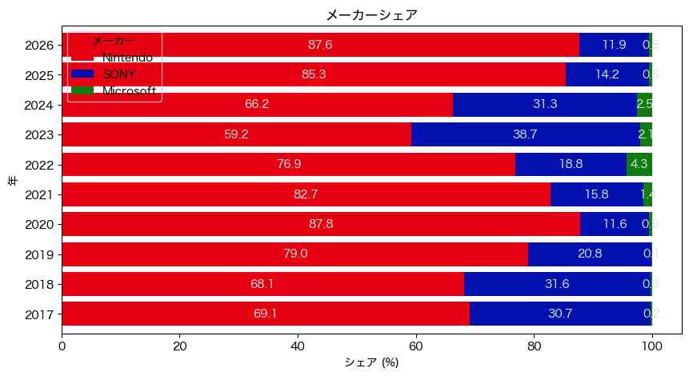

Switch2の台数減少の影響で任天堂のシェアが87.8%から87.6%に若干減少しました｡